# Transaction Data - Part 2: RFM Analysis & Customer Segmentation

### 2x Clusters

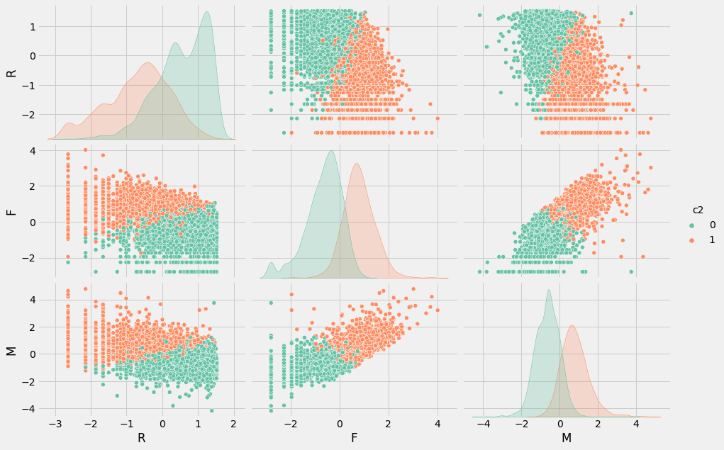

```python
clusterplot(rfm_s, 'c2')
```

```python
cluster_summary(rfm, 'c2', 'mean')
```

| c2 | R | F | M | count | %_rev | %_count |
| --- | --- | --- | --- | --- | --- | --- |
| 1 | 30.5 | 168.5 | 3869.6 | 1905 | 0.87 | 0.45 |
| 0 | 134.9 | 24.3 | 457.8 | 2361 | 0.13 | 0.55 |

Commentary:

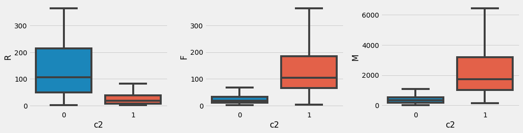

```python
rfmbox(rfm, 'c2', False)
```

### 3x Clusters

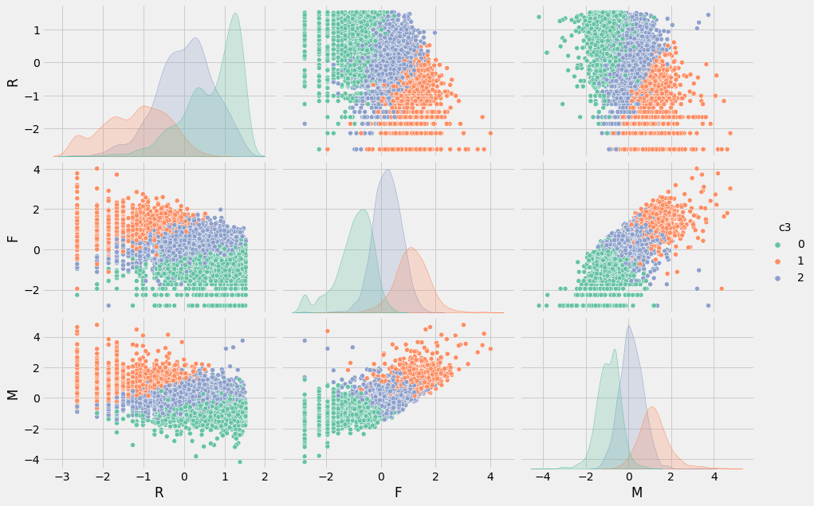

```python
clusterplot(rfm_s, 'c3')
```

```python
cluster_summary(rfm, 'c3', 'mean')
```

| c3 | R | F | M | count | %_rev | %_count |
| --- | --- | --- | --- | --- | --- | --- |
| 1 | 12.9 | 255.0 | 6348.2 | 932 | 0.70 | 0.22 |
| 2 | 67.6 | 64.7 | 1152.4 | 1833 | 0.25 | 0.43 |
| 0 | 160.3 | 14.7 | 282.1 | 1501 | 0.05 | 0.35 |

Commentary:

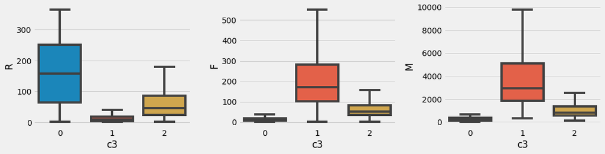

```python
rfmbox(rfm, 'c3', False)
```

### 4x Clusters

```python
cluster_summary(rfm, 'c4', 'mean')
```

| c4 | R | F | M | count | %_rev | %_count |
| --- | --- | --- | --- | --- | --- | --- |
| 2 | 12.0 | 278.0 | 6979.5 | 815 | 0.67 | 0.19 |
| 1 | 90.6 | 79.4 | 1504.4 | 1255 | 0.22 | 0.29 |
| 3 | 19.6 | 38.1 | 575.5 | 849 | 0.06 | 0.20 |
| 0 | 175.5 | 14.7 | 287.7 | 1347 | 0.05 | 0.32 |

# Percentile splits

An alternative approach to segmentation is to apply percentile splits to score customers on each of the categories which enables a more targeted and pre-defined approach to segmentation.

We shall apply this to customer segment '1' identified by the K-means 2 cluster segementation. This segment included 1,905 customers (45% of total customers) who make up 87% of revenue. These customers exhibited Lower recency, Higher Frequency & Higher Monetary Value.

```python
# filter on c2 = 1
segment = rfm[rfm.c2 == 1][['R', 'F', 'M']]

# inspect
segment.describe().round(2)
```

|  | R | F | M |
| --- | --- | --- | --- |
| count | 1905.00 | 1905.00 | 1905.00 |
| mean | 30.52 | 168.50 | 3869.56 |
| std | 37.30 | 312.05 | 12677.84 |
| min | 1.00 | 3.00 | 150.61 |
| 25% | 8.00 | 65.00 | 1031.41 |
| 50% | 18.00 | 104.00 | 1743.15 |
| 75% | 38.00 | 185.00 | 3189.81 |
| max | 337.00 | 7528.00 | 279138.02 |

Note the significant variance within this segment. Let's segment this group further by applying a percentile based score for Recency, Frequency and Monetary Value to each customer.

```python
# create labels and assign them to percentile groups
r_labels = range(3, 0, -1)
r_groups = pd.qcut(segment.R, q = 3, labels = r_labels)

f_labels = range(1, 4)
f_groups = pd.qcut(segment.F, q = 3, labels = f_labels)

m_labels = range(1, 4)
m_groups = pd.qcut(segment.M, q = 3, labels = m_labels)
```

```python
# make a new column for group labels
segment['R_score'] = r_groups.values
segment['F_score'] = f_groups.values
segment['M_score'] = m_groups.values
# combine the scores to create segments
segment['RFM_segment'] = segment.apply(lambda x: str(x['R_score']) + str(x['F_score']) + str(x['M_score']), axis = 1)
```

Let's pick out the customers who scored poorly in 1 measure, but well in the other two.

```python
# identify segments for targeted marketing
target = segment[   (segment.RFM_segment == '133') |
                    (segment.RFM_segment == '313') |
                    (segment.RFM_segment == '331')     ]
```

```python
cluster_summary(target, 'RFM_segment', 'mean').drop(columns=['%_rev',	'%_count'])
```

| RFM_segment | R | F | M | count |
| --- | --- | --- | --- | --- |
| 133 | 55.9 | 253.0 | 5355.3 | 83 |
| 313 | 5.8 | 40.4 | 17619.0 | 20 |
| 331 | 3.9 | 221.9 | 944.4 | 17 |

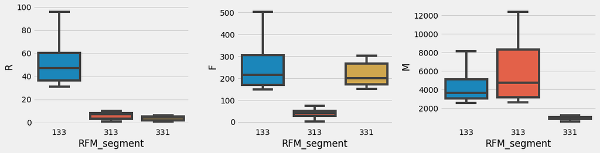

```python
rfmbox(target, 'RFM_segment', False)
```

Seperating out the customers who have scored lowest in one variable but highest in the other two can could help to develop targeted marketing approaches for each. For example:

- '133' - low score on recency implies that we may need to re-engage the customer
- '313' - low score on Frequency implies that these could be valuable new or occasional customers that might benefit from welcome rewards or loyalty programs.
- '331' - low score on Monetary Value suggests that these customers are highly engaged but not spending large amounts of money per order. They could be responsive to loyalty rewards and upselling.